# Recruitment DFA data processing

```r
# Calculate mean SSB weight for sardine
matProp <- read_csv(file = "C:/Users/r.wildermuth/Documents/FutureSeas/SardineMSE/dat/maturityAtAge_02092022.csv")
sardSSBwt <- waa %>% filter(scientificName == "Sardinops sagax") %>%
                full_join(y = matProp, by = c("age" = "Age")) %>%
                mutate(meanSSBwt = avgWAA * PropMature) %>%
                group_by(scientificName, year, seas) %>%
                summarize(meanSSBwt = mean(meanSSBwt))
```

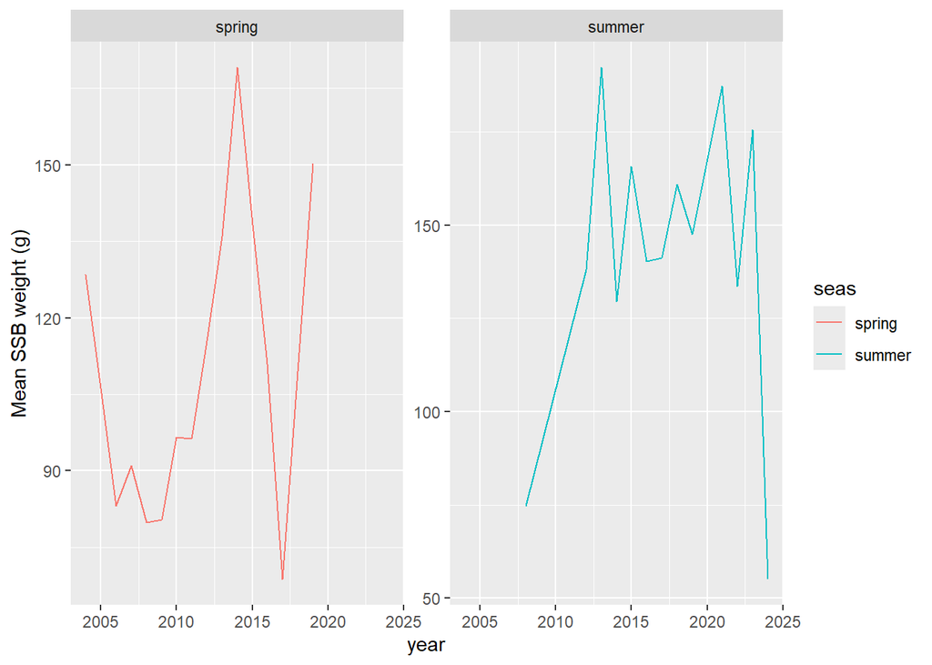

```r
sardSSBwt %>% ggplot(aes(x = year, y = meanSSBwt, color = seas)) +
  geom_line() +
  facet_wrap(~seas, scales = "free_y") +
  labs(y = "Mean SSB weight (g)")
```

Weight-length residuals using data from Caitlin Allen Akselrud 6/2/2025

```r
atBiolDat <- read_csv(file= paste0(datPath, "raw_trawl_specimen_data.csv"))
```

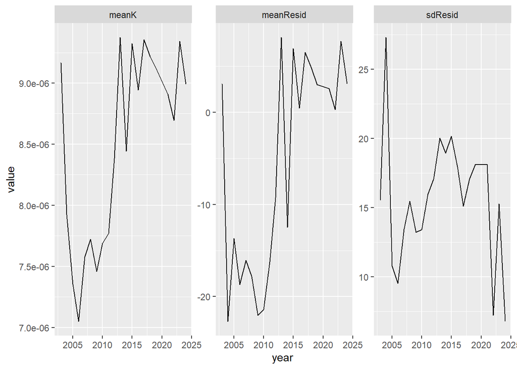

```r
# get estimated length intervals, assuming extra
lengths <- data.frame(lenSL = seq(from = min(atBiolDat$standardLength_mm, na.rm = TRUE),
                                  to = max(atBiolDat$standardLength_mm, na.rm = TRUE),
                                  by = 1))
# convert to total length mm
lengths$lenTL <- atm::convert_length(scientificName = "Sardinops sagax",
                                     L.in = lengths$lenSL,
                                     from = "SL", to = "TL")

lengths$weight_est <- atm::estimate_weight(scientificName = "Sardinops sagax",
                                           season = 1, model.type = "GLM",
                                           totalLength_mm = lengths$lenTL)

atBiolDat <- atBiolDat %>% left_join(y = lengths, by = c("standardLength_mm" = "lenSL")) %>%
                mutate(year = year(final_date),
                       wtResid = weightg - weight_est,
                       condK = weightg/(lenTL^3)) %>%
                filter(sex == "female", standardLength_mm >= 160) %>%
                group_by(year) %>%
                summarize(meanResid = mean(wtResid, na.rm = TRUE),
                          sdResid = sd(wtResid, na.rm = TRUE),
                          meanK = mean(condK, na.rm = TRUE))

atBiolDat %>% pivot_longer(cols = -year, names_to = "variable", values_to = "value") %>%
  ggplot(aes(x = year, y = value)) +
  geom_line() +
  facet_wrap(~variable, scales = "free_y")
```

# Zooplankton data

```r
zooplkn <- read_csv(file= paste0(datPath, "AtlantisModel_C_biomass_data_31Mar2021.csv"),
                    na = "NaN")
zooplkn <- zooplkn %>% mutate(Time = mdy_hm(Time),
                              year = year(Time), month = month(Time),
                              seas = case_when(month %in% 1:6 ~ "spring",
                                               month %in% 7:12 ~ "summer")) %>%
              filter(!is.na(year))
```

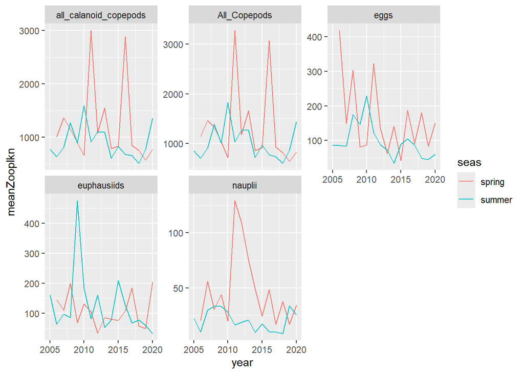

```r
# adding Atlantis groupings from Pierre-Yves definitions
zooplkn <- zooplkn %>%
              mutate(atlGrp = case_when(Class %in% c("salps","pyrosomes",
                                                     "ctenophora", "cnidaria") ~ "Gelatinous",
                             Class %in% c("polychaete","crustacea_others",
                                          "chaetognatha","appendicularia",
                                          "euphausiids") ~ "Large zooplankton",
                             Class %in% c("pteropoda") ~ "Pteropods",
                             Class %in% c("radiolarians","foraminifera") ~ "Microzooplankton",
                             Class %in% c("all_calanoid_copepods","All_Copepods",
                                          "doliolids","ostracods", "nauplii") ~ "Mesozooplankton",
                             Class %in% c("eggs","others","bryozoan_larvae") ~ "Others",
                             TRUE ~ "NA"))

# Plot copepods, nauplii, eggs and euphausiids over time
zooplkn %>% group_by(Class, year, seas) %>%
  summarize(meanZooplkn = mean(`Carbon Biomass Sum (mgC m-2)`)) %>%
  filter(Class %in% c("all_calanoid_copepods","All_Copepods", "nauplii",
                      "eggs", "euphausiids")) %>%
  ggplot(aes(x = year, y = meanZooplkn, color = seas)) +
  geom_line() +
  facet_wrap(~Class, scales = "free_y")
```

Size fraction data for nauplii and copepods

```r
copepodSize <- read_csv(file= paste0(datPath, "SpringPRPOOSdata_Copepods_sizeFractions.csv"),
                    na = "NaN")
copepodSize <- copepodSize %>% mutate(Time_PST = dmy_hms(Time_PST),
                                      year = year(Time_PST), month = month(Time_PST)) %>%
                  filter(!is.na(year),
                         Night0Day1 == 1) # larvae only forage during day

# need to get total biomass C per year
copTotBio <- copepodSize %>% group_by(year) %>%
              summarize(totBio = sum(Carbon_mg_sum))

copMeanSize <- copepodSize %>%
                  mutate(size = str_match(string = `Size Range (Major Axis)`, pattern = "-\\s*(.*?)\\s*mm")[,2],
                         size = as.numeric(size),
                         numProd = size * ugcarbon_n) %>%
                  group_by(year, `Size Range (Major Axis)`, size) %>%
                  summarize(totSize = sum(ugcarbon_n),
                            copMeanSize = sum(numProd),
                            copBioSize = sum(Carbon_mg_sum)) %>%
                  full_join(y = copTotBio, by = "year") %>%
                  mutate(copPropBioSize = (copBioSize/totBio)*(size-0.25)) %>%
                  group_by(year) %>%
                  summarize(totSize = sum(totSize),
                            copMeanSize = sum(copMeanSize),
                            copPropBioSize = sum(copPropBioSize)) %>%
                  mutate(copMeanSize = copMeanSize/totSize)
```

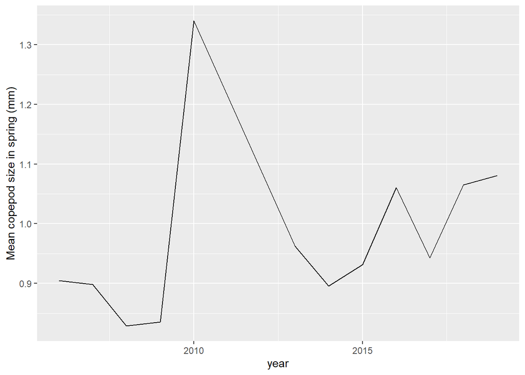

```r
copMeanSize %>% ggplot(aes(x = year, y = copMeanSize)) +
  geom_line() +
  labs(y = "Mean copepod size in spring (mm)")
```

```r
# -- nauplii
naupliiSize <- read_csv(file= paste0(datPath, "SpringPRPOOSdata_Nauplii_sizeFractions.csv"),
                    na = "NaN")
naupliiSize <- naupliiSize %>% mutate(Time_PST = dmy_hms(Time_PST),
                                      year = year(Time_PST), month = month(Time_PST)) %>%
                  filter(!is.na(year))

# need to get total biomass C per year
naupTotBio <- naupliiSize %>% group_by(year) %>%
              summarize(totBio = sum(Carbon_mg_sum))

naupMeanSize <- naupliiSize %>%
                  mutate(size = str_match(string = `Size Range (Major Axis)`, pattern = "-\\s*(.*?)\\s*mm")[,2],
                         size = as.numeric(size),
                         numProd = size * ugcarbon_n) %>%
                  group_by(year, `Size Range (Major Axis)`, size) %>%
                  summarize(totSize = sum(ugcarbon_n),
                            naupMeanSize = sum(numProd),
                            naupBioSize = sum(Carbon_mg_sum)) %>%
                  full_join(y = naupTotBio, by = "year") %>%
                  mutate(naupPropBioSize = (naupBioSize/totBio)*(size-0.25)) %>%
                  group_by(year) %>%
                  summarize(totSize = sum(totSize),
                            naupMeanSize = sum(naupMeanSize),
                            naupPropBioSize = sum(naupPropBioSize)) %>%
                  mutate(naupMeanSize = naupMeanSize/totSize)
```

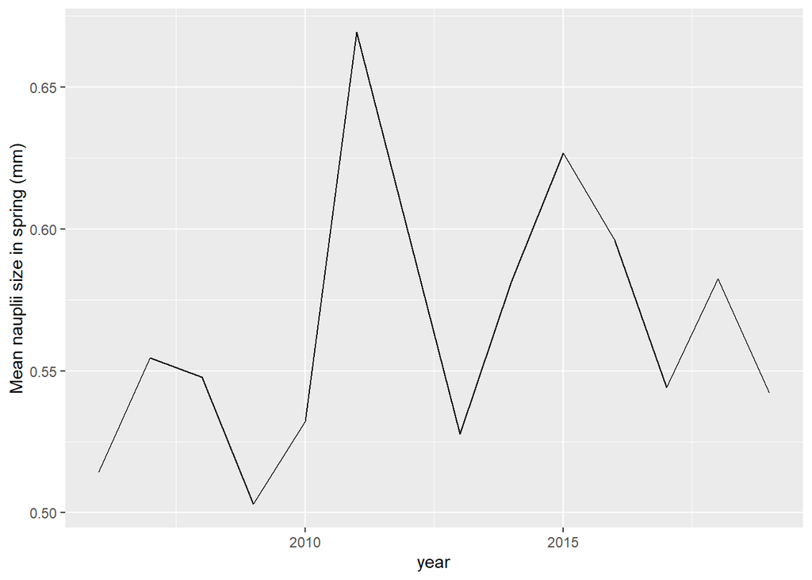

```r
naupMeanSize %>% ggplot(aes(x = year, y = naupMeanSize)) +
  geom_line() +
  labs(y = "Mean nauplii size in spring (mm)")
```

Standardized copepod indices

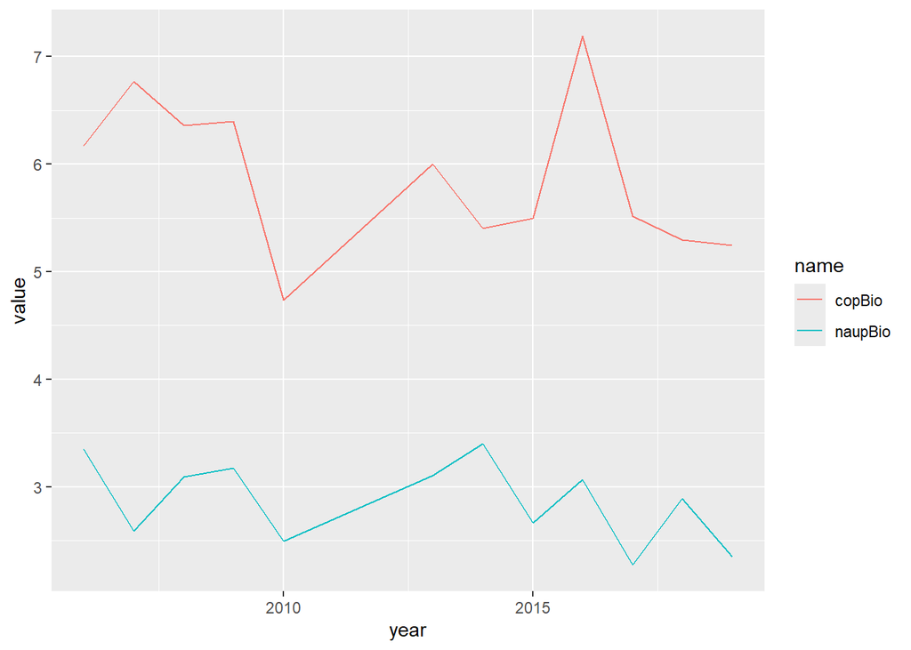

```r
load(file = paste0(datPath,"copepodIndex.RData"))

yr.vec <- names(coef(copFit))
yr.vec <- as.numeric(str_extract(yr.vec, "\\d+"))
yr.vec <- c(2006, yr.vec[which(yr.vec > 1900)])
copGAM <- data.frame(year = yr.vec,
                      copGAMcoef = as.vector(coef(copFit))[1:length(yr.vec)])
copGAM$copBio <- coef(copFit)[1]
copGAM <- copGAM %>% mutate(copBio = copBio + c(0, copGAMcoef[2:length(yr.vec)]))

load(file = paste0(datPath, "naupliiIndex.RData"))
copGAM$naupBio <- coef(naupFit)[1]
copGAM$naupGAMcoef <- as.vector(coef(naupFit))[1:length(yr.vec)]
copGAM <- copGAM %>% mutate(naupBio = naupBio + c(0, naupGAMcoef[2:length(yr.vec)]))

copGAM %>% select(year, copBio, naupBio) %>%
  pivot_longer(cols = -year) %>%
  ggplot(aes(x = year, y = value, color = name)) +
  geom_line()
```

NEMURO plankton groups

```r
# From Stefan Koenigstein (7/3/2023): "NEMURO output averaged over Mar-May and for the SoCal bight (31–34.5°N and 0-300km distance to coast, spanning -116–124°W), which overlaps pretty well with the CalCOFI core survey area. Besides the SoCal bight as discussed, I included NorCal/OR (40.5-44.5°N), in case you want to look at potential links to sardine adult feeding habitat.
# I took another look at depth distribution and ended up re-doing the merging of the two hindcasts, adjusting the older 1980-2010 hindcast to the values of the new 95-2019 one (which seems to be improved).
# In our meeting I forgot to mention that I’m currently averaging over 0-40m depth for all plankton group"
nemuroZ <- read_csv(paste0(datPath, "ROMS-NEMURO spring plankton.csv"))
```

```r
nemuroZ <- nemuroZ %>% filter(GCM == "HIST") %>%
              pivot_wider(names_from = zone, values_from = c(PS, PL, ZS, ZM, ZL))
```

Spring Calanus pacificus

```r
spCpacificus <- read_csv(paste0(datPath, "Spring copepod community for Andrew 20221116.csv"))
```

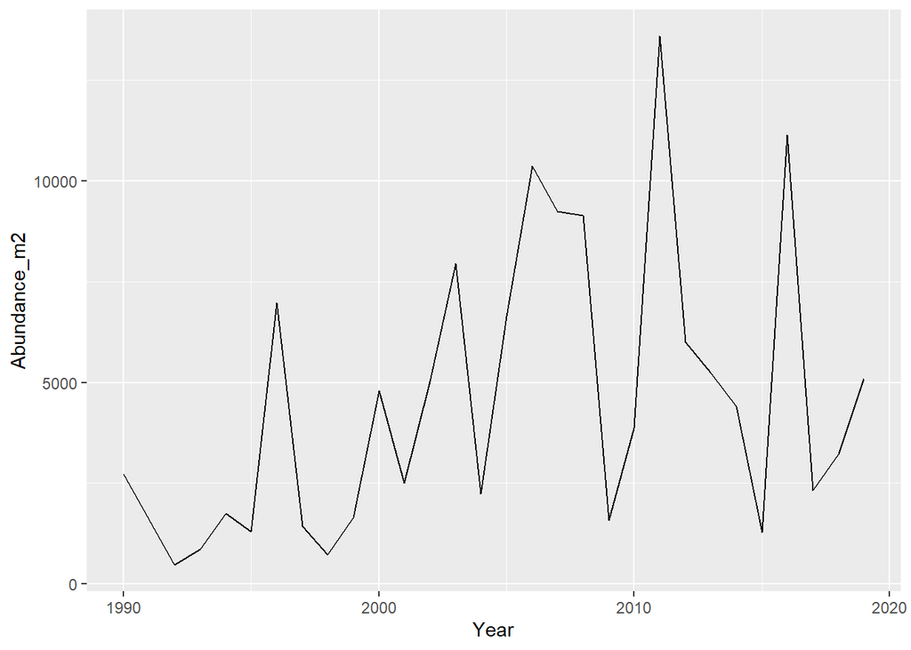

```r
spCpacificus <- spCpacificus %>% filter(Species_new == "Calanus pacificus")

spCpacificus %>%
  filter(Year >= 1990) %>%
  ggplot(aes(x = Year, y = Abundance_m2)) +
  geom_line()
```

# Species distribution model outputs

Spawning habitat area and duration are calculated from ROMS-based species distribution models produced by Barb Muhling and downloaded 3/29/2023. Habitat predictions are derived from SDMs without SSB included as a predictor. For now using only GAM estimates of SDM.

From conversation with Barb on 3/29/23: - ROMS-based estimates have more predictors, thus better predictions of habitat - ROMS sample frame likely represents northern Pacific sardine stock better - ROMS predictions need updates before final version of analysis

## Spawning habitat area

```r
# sardine spawning season
sardFiles <- expand.grid("sard", 3:7, 1998:2023, "mboost_roms.nc") %>%
                    mutate(sdmFile = paste(Var1, Var2, Var3, Var4, sep = "_")) %>%
                    pull(sdmFile)

sardFiles <- paste0(datPath, "SDMoutput/sardine_noSSB/", sardFiles)
sardSDMs <- read_stars(sardFiles, proxy = FALSE, quiet = TRUE)
```

[output not shown]

[output cut: 75 more lines]

[output not shown]

```r
# Time fix from Barb
wrongTimes <- as.Date(st_get_dimension_values(sardSDMs, "time"))
wrongTimes[c(1, length(wrongTimes))] # Can see is wrong baseline
```

```
##      3_19981     7_202331
## "0099-03-17" "0124-08-16"
```

```r
rightTimes <- wrongTimes + 693579 # 693579 is the number of days since 0000-00-00
sardSDMs <- st_set_dimensions(sardSDMs, 3, values = rightTimes, names = "time")
st_get_dimension_values(sardSDMs, "time")[c(1, length(wrongTimes))] # Check times look ok now
```

```
##      3_19981     7_202331
## "1998-03-01" "2023-07-31"
```

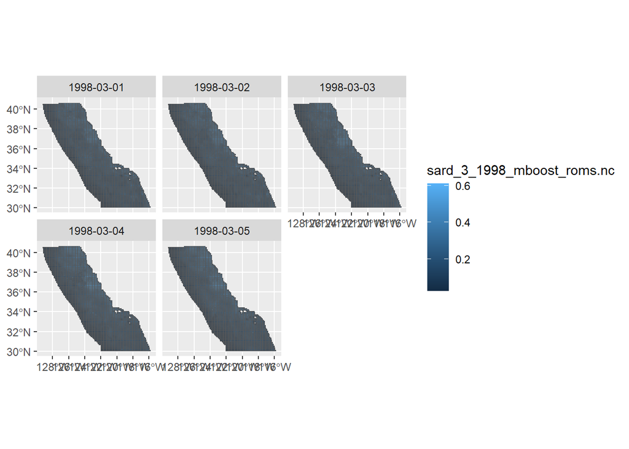

```r
st_crs(sardSDMs) <- "+proj=longlat +ellps=WGS84 +datum=WGS84"
sardSDMs <- st_transform(sardSDMs, "+proj=longlat +ellps=WGS84 +datum=WGS84")
#st_get_dimension_values(sardSDMs, "time")

# Use CalCurrent Atlantis extent to limit sample frame
ccAtl <- st_read("C:/Users/r.wildermuth/Documents/FutureSeas/MapFiles/emocc_whole_domain.shp")
ccAtl <- st_transform(ccAtl, "+proj=longlat +ellps=WGS84 +datum=WGS84")

# restrict to area south of 40deg N
newAtlbbox <- st_bbox(ccAtl)
newAtlbbox$ymax <- 40.0
newAtlbbox <- st_bbox(unlist(newAtlbbox))
ccAtl <- st_crop(ccAtl, newAtlbbox)
# crop to Atlantis extent
sardSDMs <- st_crop(x = sardSDMs,
                      y = ccAtl)
# show first 5 days of SDM
sardSlice <- slice(sardSDMs, index = 1:5, along = "time")
ggplot() + geom_stars(data = sardSlice) + facet_wrap(~time)
```

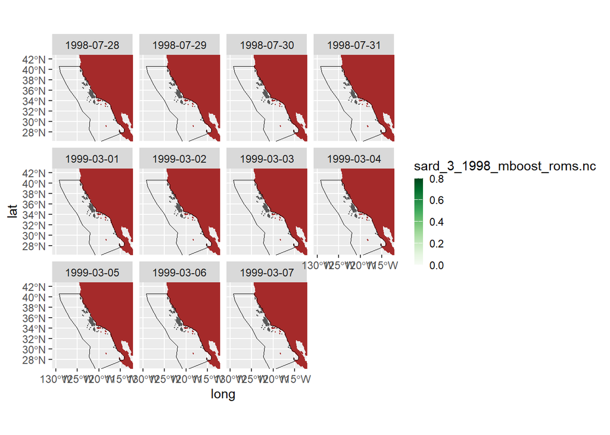

```r
# Calculate high probability habitat
probMean <- mean(sardSDMs$sard_3_1998_mboost_roms.nc, na.rm = TRUE)
probSD <- sd(sardSDMs$sard_3_1998_mboost_roms.nc, na.rm = TRUE)
upper95 <- probMean + 1.96*probSD
# discrimination threshold from Barb Muhling:
sardHabThresh <- 0.45

# Try masking low probability cells
sardSpawn <- sardSDMs
sardSpawn[sardSDMs < sardHabThresh] <- NA
# Don't allow spawning habitat above 40deg north
#sardSpawn2 <- sardSpawn %>% filter(y < 40)

sardSpawnSlice <- slice(sardSpawn, index = 150:160, along = "time")
#ggplot() + geom_stars(data = sardSpawnSlice) + facet_wrap(~time)

# Map prep
pac.coast <- borders("world", colour="brown", fill="brown", xlim = c(-140, -100), ylim = c(20, 60))
mycols <- RColorBrewer::brewer.pal(9, "Greens")#colors()[c(473,562,71,610,655,653,621,34)]
mypalette <- colorRampPalette(mycols)(255)

ggplot() +
  geom_stars(data = sardSpawnSlice) +
  scale_fill_gradientn(colours = mypalette, limits = c(0, 0.8), na.value = NA) +
  guides(fill = guide_colorbar(barwidth=0.5, barheight=5)) +
  pac.coast +
  geom_sf(data = ccAtl, color = "black", size = 1.5, fill = NA) +
  coord_sf(xlim = c(-130, -113), ylim = c(27, 42)) +
  facet_wrap(~time)
```

```r
sardSpawnYr <- aggregate(sardSpawn, by = "years", FUN = sum, na.rm = TRUE)
st_get_dimension_values(sardSpawnYr, "time")
```

```
##  [1] "1998-01-01" "1999-01-01" "2000-01-01" "2001-01-01" "2002-01-01"
##  [6] "2003-01-01" "2004-01-01" "2005-01-01" "2006-01-01" "2007-01-01"
## [11] "2008-01-01" "2009-01-01" "2010-01-01" "2011-01-01" "2012-01-01"
## [16] "2013-01-01" "2014-01-01" "2015-01-01" "2016-01-01" "2017-01-01"
## [21] "2018-01-01" "2019-01-01" "2020-01-01" "2021-01-01" "2022-01-01"
## [26] "2023-01-01"
```

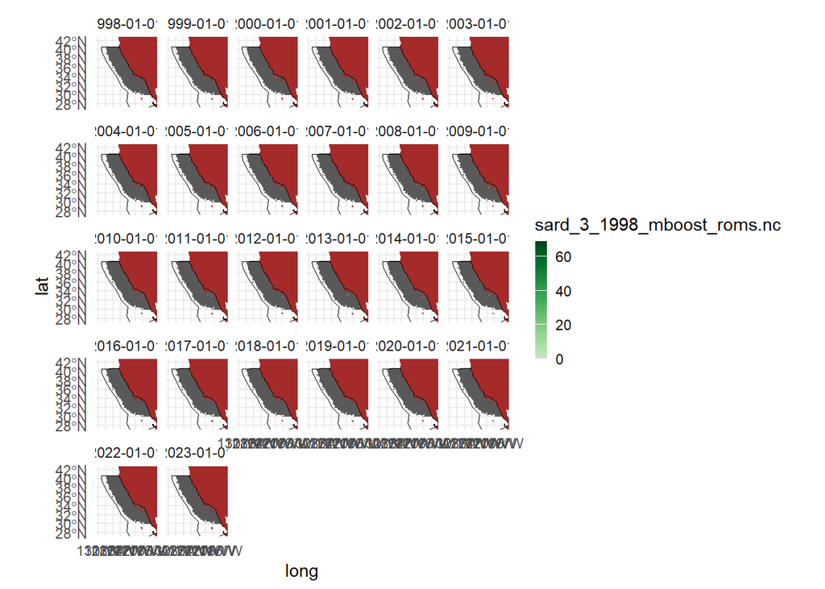

```r
# reorder and then make 0s NAs to turn them grey
sardSpawnYr <- aperm(sardSpawnYr, c(2,3,1))
sardSpawnYr[sardSpawnYr == 0] <- NA

ggplot() +
  geom_stars(data = sardSpawnYr) +
  pac.coast +
  geom_sf(data = ccAtl, color = "black", size = 1.5, fill = NA) +
  scale_fill_gradientn(colours = mycols[3:9],
                       limits = c(0, max(sardSpawnYr$sard_3_1998_mboost_roms.nc,
                                         na.rm = TRUE)),
                       na.value = NA) +
  guides(fill = guide_colorbar(barwidth=0.5, barheight=5)) +

  coord_sf(xlim = c(-130, -115), ylim = c(28, 42)) +
  facet_wrap(~time) +
  theme_minimal()
```

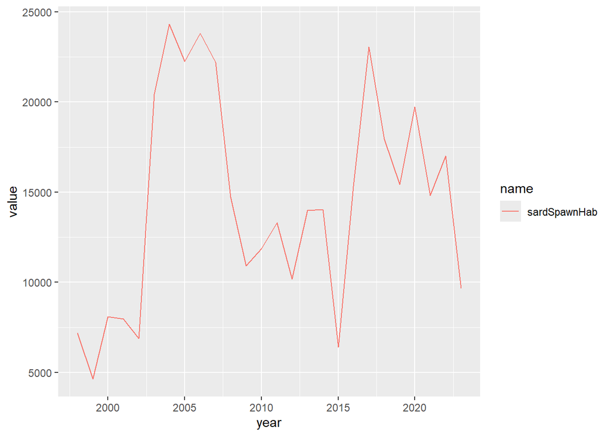

```r
sardSpawnHab <- aggregate(sardSpawnYr, ccAtl, FUN = sum, na.rm = TRUE)

spawnTS <- data.frame(year = 1998:2023,
                      sardSpawnHab = t(sardSpawnHab$sard_3_1998_mboost_roms.nc))

spawnTS %>% pivot_longer(cols = c("sardSpawnHab")) %>%
  ggplot() +
  geom_line(aes(x = year, y = value, col = name))
```

## Spawning season timing and duration

Two options for spawning timing: 1. Hierarchical process of determining spawning area from yearly maps using rules for spawning area to create possible spawning area polygon, then indicating date at which some threshold of cells reach breeding habitat probability threshold within that area. 2. Similar to 1), but using polygon derived from CalCOFI stations with high proportion of larval catches throughout the survey.

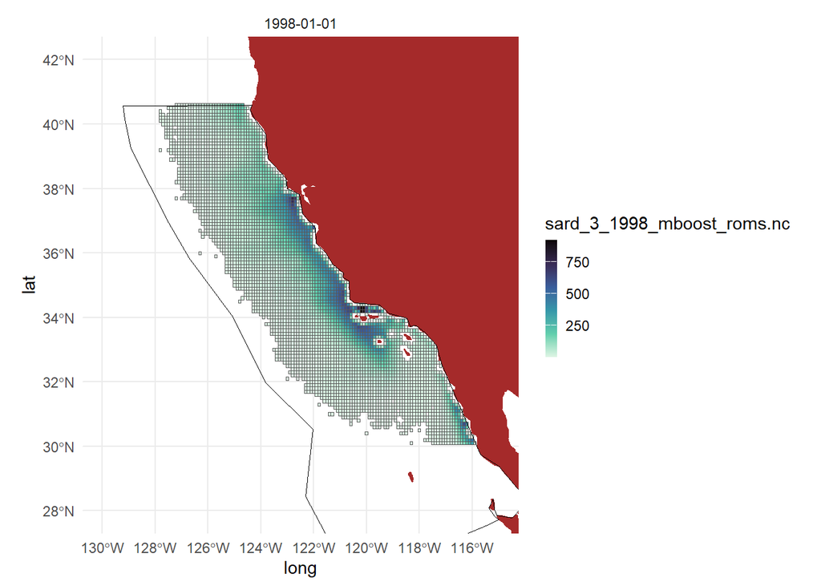

```r
# aggregate over time
by_t <- as.Date(c("1998-01-01", "2023-01-01"))
sardSpawnGrounds <- aggregate(sardSpawnYr, by = by_t, FUN = sum,
                              na.rm = TRUE, rightmost.closed = TRUE)
# rearrange the dimensions and get only the aggregated time slice
sardSpawnGrounds <- aperm(sardSpawnGrounds, c(2,3,1))
sardSpawnGrounds <- sardSpawnGrounds[, , , 1]

sardSpawnGroundsCont <- sardSpawnGrounds
sardSpawnGroundsCont[sardSpawnGrounds == 0] <- NA

ggplot() +
  geom_stars(data = sardSpawnGroundsCont) +
  pac.coast +
  geom_sf(data = ccAtl, color = "black", size = 1.5, fill = NA) +
  scale_fill_viridis_c(option = "mako",
                       direction = -1,
                       na.value = NA) +
  guides(fill = guide_colorbar(barwidth=0.5, barheight=5)) +

  coord_sf(xlim = c(-130, -115), ylim = c(28, 42)) +
  facet_wrap(~time) +
  theme_minimal()
```

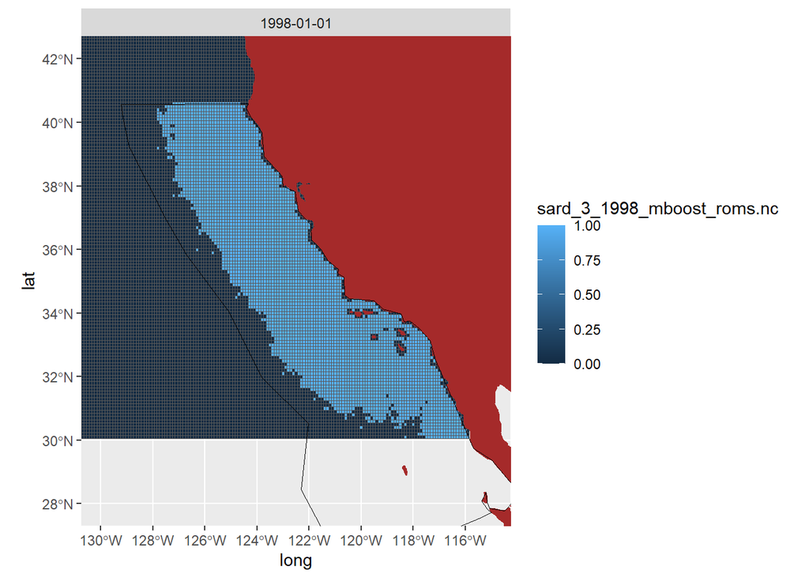

```r
# Change to categorical (1 = in spawning grounds)
sardSpawnGrounds[sardSpawnGrounds > 0] <- 1


ggplot() +
  geom_stars(data = sardSpawnGrounds) +
  pac.coast +
  geom_sf(data = ccAtl, color = "black", size = 1.5, fill = NA) +
  coord_sf(xlim = c(-130, -115), ylim = c(28, 42)) +
  facet_wrap(~time)
```

```r
# save(sardSpawnGrounds, file = paste0(datPath, "histSardSpawnGr.RData"))
```

Find proportion of breeding habitat in spawning ground

```r
# convert spawning days to categorical
sardSpawn1NA <- sardSpawn
# find number of high probability cells at each time
sardAggSpwn <- aggregate(sardSpawn1NA, by = ccAtl, FUN = sum, na.rm = TRUE)
sardAggSpwn <- t(sardAggSpwn$sard_3_1998_mboost_roms.nc)
sardSpawn1NA[sardSpawn > sardHabThresh] <- 1 # should only be NAs and 1s

# find number of cells in spawning grounds
sardSpGrdDenom <- aggregate(sardSpawnGrounds, by = ccAtl, FUN = sum, na.rm = TRUE)
sardSpGrdDenom <- as.numeric(sardSpGrdDenom$sard_3_1998_mboost_roms.nc)

# find number of high probability cells at each time
sardSpGrdNum <- aggregate(sardSpawn1NA, by = ccAtl, FUN = sum, na.rm = TRUE)
sardSpGrdNum <- t(sardSpGrdNum$sard_3_1998_mboost_roms.nc)

sardSpDates <- data.frame(date = st_get_dimension_values(sardSpawn, which = "time"),
                          propSpawn = sardSpGrdNum/sardSpGrdDenom,
                          aggSpawn = sardAggSpwn) %>%
                  mutate(year = year(ymd(date)),
                         dayofYr = yday(date))

summary(sardSpGrdNum/sardSpGrdDenom)
```

```
##        V1
##  Min.   :0.00000
##  1st Qu.:0.01602
##  Median :0.03497
##  Mean   :0.04379
##  3rd Qu.:0.06249
##  Max.   :0.25265
```

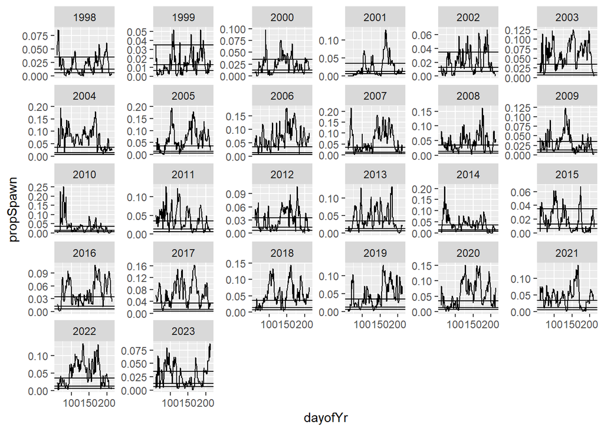

```r
sardSpDates %>% #filter(year == 2015) %>%
  ggplot(aes(x = dayofYr, y = propSpawn)) +
  geom_line() +
  geom_hline(yintercept = quantile(sardSpGrdNum/sardSpGrdDenom, probs = c(0.1, 0.2, 0.5))) +
  facet_wrap(~year, scales = "free_y")
```

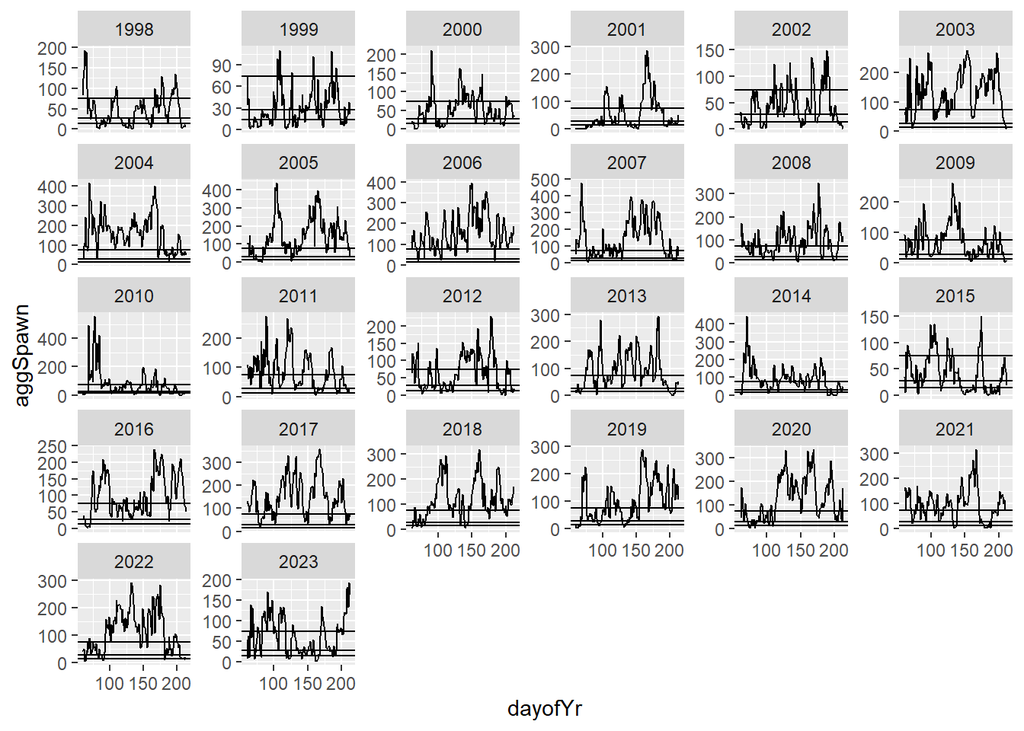

```r
sardSpDates %>% #filter(year == 2015) %>%
  ggplot(aes(x = dayofYr, y = aggSpawn)) +
  geom_line() +
  geom_hline(yintercept = quantile(sardAggSpwn, probs = c(0.1, 0.2, 0.5))) +
  facet_wrap(~year, scales = "free_y")
```

```r
# Calculate number of days 5% of spawning grounds contain high quality habitat
sardSpawnDays <- sardSpDates %>% filter(propSpawn >= 0.05) %>%
                    group_by(year) %>%
                    summarize(daysAbove5pct = n())
```

## Nursury habitat area

```r
# sardine spawning season
sardFiles <- expand.grid("sardLarvae", 3:7, 1998:2023, "mboost_roms.nc") %>%
                    mutate(sdmFile = paste(Var1, Var2, Var3, Var4, sep = "_")) %>%
                    pull(sdmFile)

sardFiles <- paste0(datPath, "SDMoutput/sardine_larvae/", sardFiles)
sardLarvSDMs <- read_stars(sardFiles, proxy = FALSE, quiet = TRUE)
```

[output not shown]

[output cut: 75 more lines]

[output not shown]

```r
# Time fix from Barb
wrongTimes <- as.Date(st_get_dimension_values(sardLarvSDMs, "time"))
wrongTimes[c(1, length(wrongTimes))] # Can see is wrong baseline
```

```
##      3_19981     7_202331
## "0099-03-17" "0124-08-16"
```

```r
rightTimes <- wrongTimes + 693579 # 693579 is the number of days since 0000-00-00
sardLarvSDMs <- st_set_dimensions(sardLarvSDMs, 3, values = rightTimes, names = "time")
st_get_dimension_values(sardLarvSDMs, "time")[c(1, length(wrongTimes))] # Check times look ok now
```

```
##      3_19981     7_202331
## "1998-03-01" "2023-07-31"
```

```r
st_crs(sardLarvSDMs) <- "+proj=longlat +ellps=WGS84 +datum=WGS84"
sardLarvSDMs <- st_transform(sardLarvSDMs, "+proj=longlat +ellps=WGS84 +datum=WGS84")
#st_get_dimension_values(sardLarvSDMs, "time")

# crop to Atlantis extent
sardLarvSDMs <- st_crop(x = sardLarvSDMs,
                      y = ccAtl)
# Calculate high probability habitat
probMean <- mean(sardLarvSDMs$sard_3_1998_mboost_roms.nc, na.rm = TRUE)
```

```r
probSD <- sd(sardLarvSDMs$sard_3_1998_mboost_roms.nc, na.rm = TRUE)
upper95 <- probMean + 1.96*probSD
# discrimination threshold from Barb Muhling:
sardLarvHabThresh <- 0.17

# Try masking low probability cells
sardLarv <- sardLarvSDMs
sardLarv[sardLarvSDMs < sardLarvHabThresh] <- NA
# Don't allow spawning habitat above 40deg north
#sardSpawn2 <- sardSpawn %>% filter(y < 40)

#sardSpawnSlice <- slice(sardSpawn, index = 150:160, along = "time")
#ggplot() + geom_stars(data = sardSpawnSlice) + facet_wrap(~time)

# Map prep
pac.coast <- borders("world", colour="brown", fill="brown", xlim = c(-140, -100), ylim = c(20, 60))
mycols <- colors()[c(473,562,71,610,655,653,621,34)]
mypalette <- colorRampPalette(mycols)(255)

# ggplot() +
#   geom_stars(data = sardSpawnSlice) +
#   scale_fill_gradientn(colours = mypalette, limits = c(0, 0.8), na.value = NA) +
#   guides(fill = guide_colorbar(barwidth=0.5, barheight=5)) +
#   pac.coast +
#   geom_sf(data = ccAtl, color = "black", size = 1.5, fill = NA) +
#   coord_sf(xlim = c(-130, -113), ylim = c(27, 42)) +
#   facet_wrap(~time)

sardLarvYr <- aggregate(sardLarv, by = "years", FUN = sum, na.rm = TRUE)
st_get_dimension_values(sardLarvYr, "time")
```

```
##  [1] "1998-01-01" "1999-01-01" "2000-01-01" "2001-01-01" "2002-01-01"
##  [6] "2003-01-01" "2004-01-01" "2005-01-01" "2006-01-01" "2007-01-01"
## [11] "2008-01-01" "2009-01-01" "2010-01-01" "2011-01-01" "2012-01-01"
## [16] "2013-01-01" "2014-01-01" "2015-01-01" "2016-01-01" "2017-01-01"
## [21] "2018-01-01" "2019-01-01" "2020-01-01" "2021-01-01" "2022-01-01"
## [26] "2023-01-01"
```

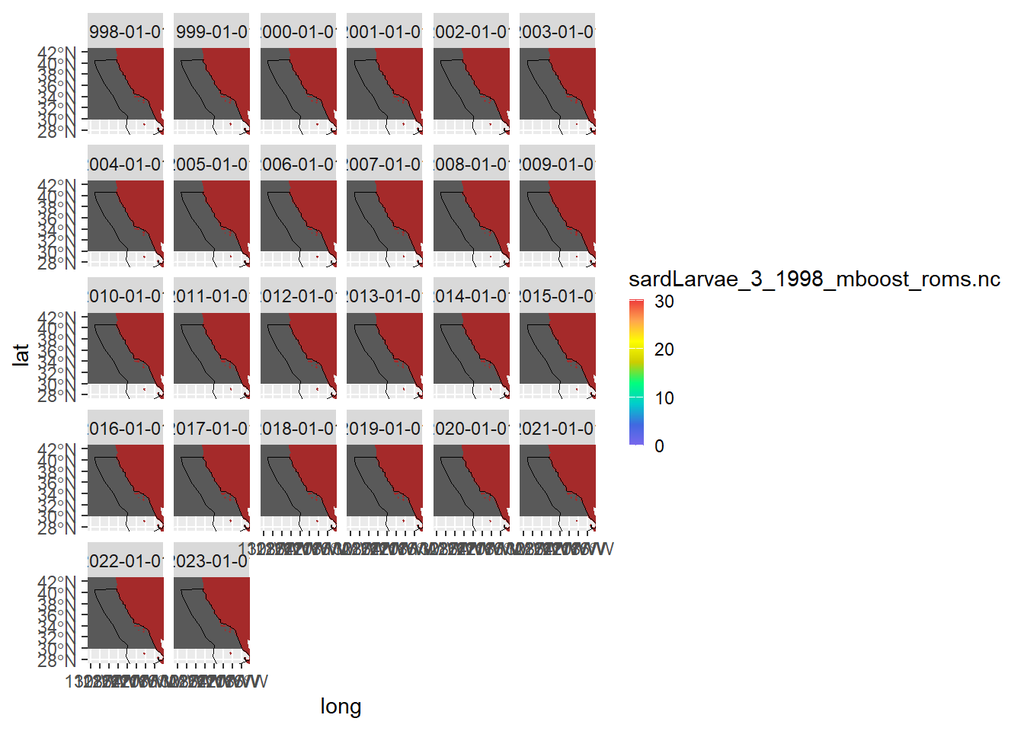

```r
ggplot() +
  geom_stars(data = aperm(sardLarvYr, c(2,3,1))) +
  pac.coast +
  geom_sf(data = ccAtl, color = "black", size = 1.5, fill = NA) +
  scale_fill_gradientn(colours = mypalette,
                       limits = c(0, max(sardLarvYr$sardLarvae_3_1998_mboost_roms.nc,
                                         na.rm = TRUE)),
                       na.value = NA) +
  guides(fill = guide_colorbar(barwidth=0.5, barheight=5)) +
  coord_sf(xlim = c(-130, -115), ylim = c(28, 42)) +
  facet_wrap(~time)
```

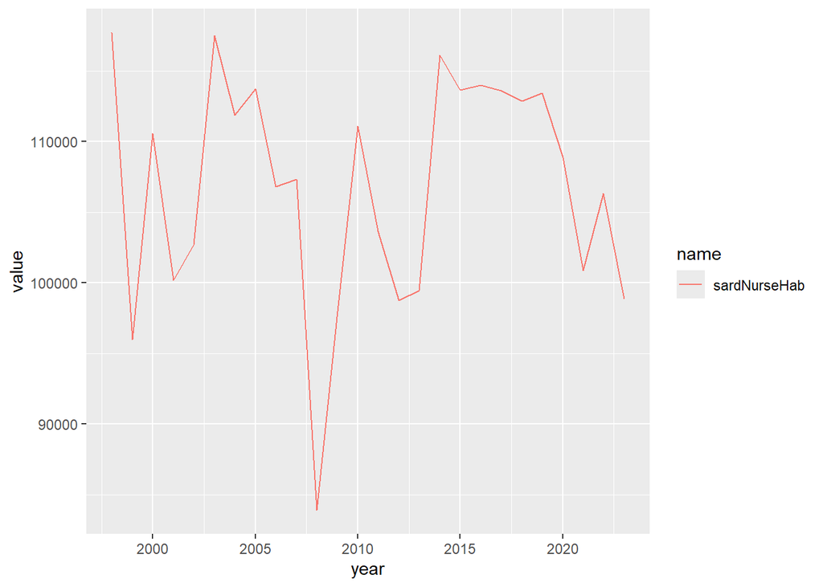

```r
sardLarvHab <- aggregate(sardLarvYr, ccAtl, FUN = sum, na.rm = TRUE)

nurseTS <- data.frame(year = 1998:2023,
                      sardNurseHab = t(sardLarvHab$sardLarvae_3_1998_mboost_roms.nc))

nurseTS %>% pivot_longer(cols = c("sardNurseHab")) %>%
  ggplot() +
  geom_line(aes(x = year, y = value, col = name))
```

# Assessment biomass and recruitment

Use Stock Synthesis-based estimates of biomass and recruitment as index variables

```r
# sardine - use r4ss package to read in from research model folder
sardVals <- SS_output("C:/Users/r.wildermuth/Documents/CEFI/SardineRecruitmentESP/SardineRecruitIndex/scenarioModels/2025_research_assessment_LorenzM",
                      verbose = FALSE, printstats = FALSE)
```

```
## Multiple files in directory match pattern *.par, choosing based on the preferences described in the help for get_par_name(): ss3.par
```

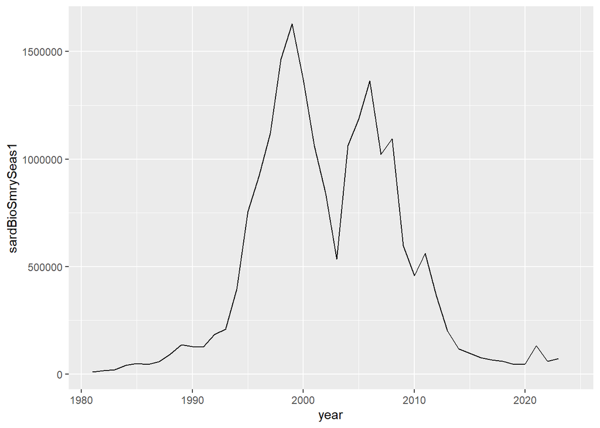

```r
sardBio <- sardVals$timeseries %>% filter(Era == "TIME") %>%
              # account for model year + S2 = next calendar year
              mutate(Yr = as.numeric(Yr),
                     year = case_when(Seas == 2 ~ Yr + 1,
                                      TRUE ~ Yr)) %>%
              select(year, Seas, Bio_smry) %>%
              pivot_wider(names_from = Seas, names_prefix = "sardBioSmrySeas",
                          values_from = Bio_smry)

sardRec <- sardVals$recruit %>% filter(era == "Main") %>%
              select(Yr, dev) %>%
              rename(sardRec = dev)

sardBio %>% ggplot(aes(x = year, y = sardBioSmrySeas1)) +
  geom_line()
```

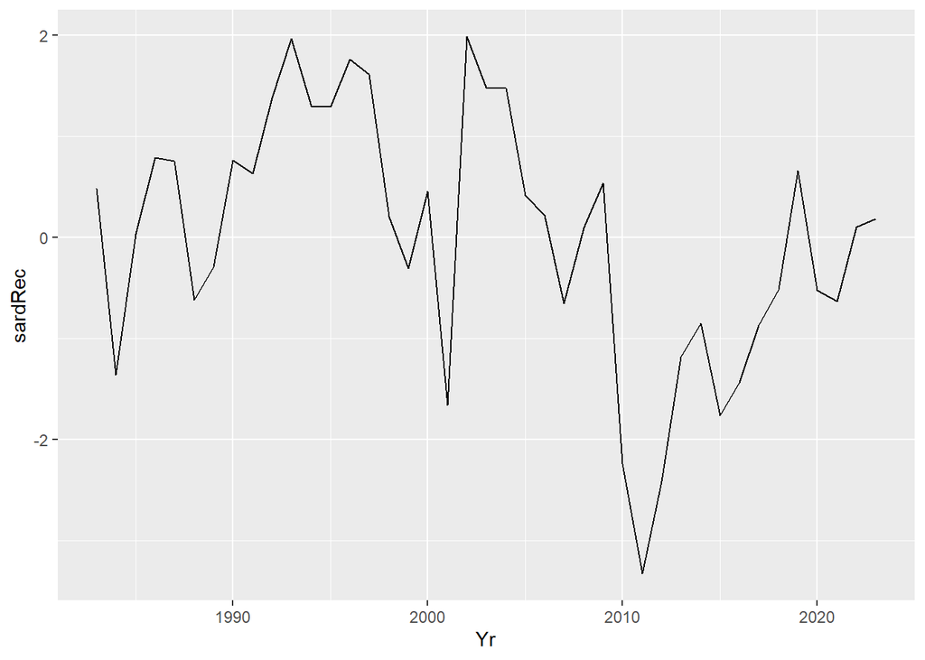

```r
sardRec %>% ggplot(aes(x = Yr, y = sardRec)) +
  geom_line()
```

```r
# anchovy
anchBio <- read_csv(paste0(datPath, "anchovySSfiles/anchovy_bio_timeseries_data_for_Robert.csv"))
anchBio <- anchBio %>% filter(Era == "TIME") %>%
              # account for model year + S2 = next calendar year
              mutate(year = case_when(Seas == 2 ~ Yr + 1,
                                      TRUE ~ Yr)) %>%
              select(year, Seas, Bio_smry) %>%
              pivot_wider(names_from = Seas, names_prefix = "anchBioSmrySeas",
                          values_from = Bio_smry)

anchRec <- read_csv(paste0(datPath, "anchovySSfiles/anchovy_rec_data_for_Robert.csv"))
```

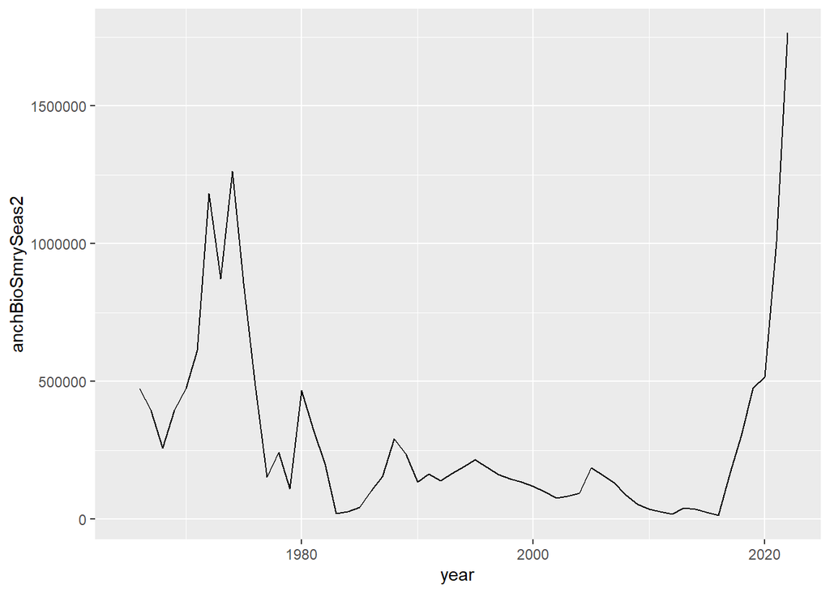

```r
anchRec <- anchRec %>% filter(era == "Main") %>%
              select(Yr, dev) %>%
              rename(anchRec = dev)

anchBio %>% ggplot(aes(x = year, y = anchBioSmrySeas2)) +
  geom_line()
```

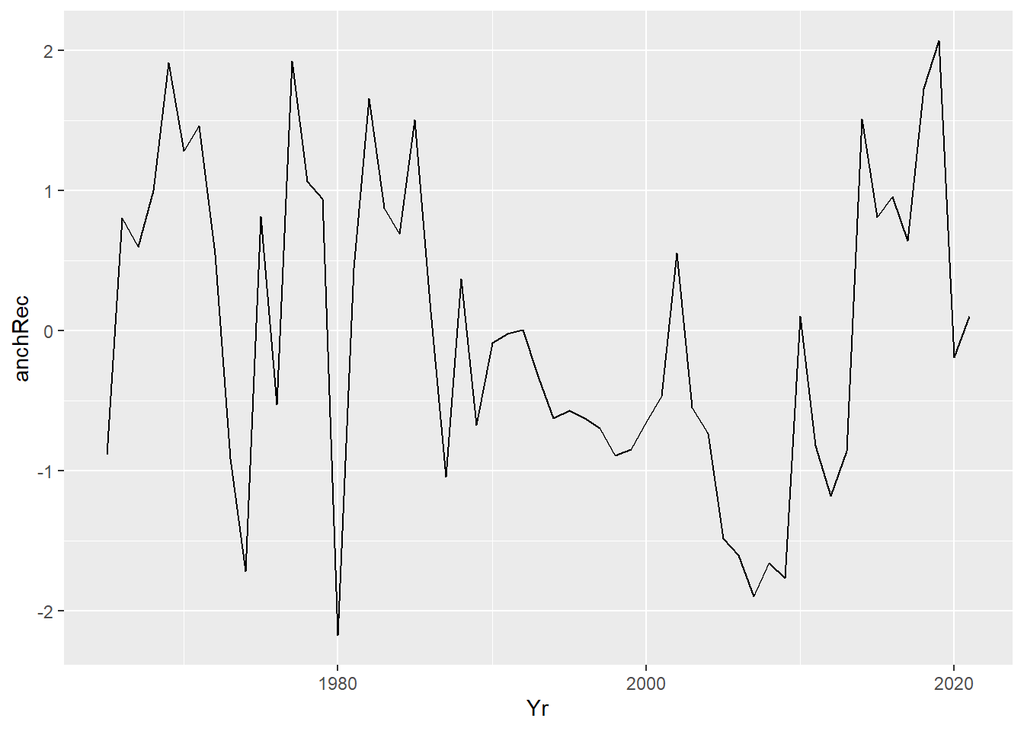

```r
anchRec %>% ggplot(aes(x = Yr, y = anchRec)) +
  geom_line()
```

# Colate timeseries

```r
# compile and save data for analysis

# only spring sardine have decent number of observations
# !!R: This doesn't hold past ~2019
waa <- waa %>% filter(age == 1, seas == "spring") %>%
          rename(age1SprSardmeanWAA = avgWAA) %>% ungroup() %>%
          select(year, age1SprSardmeanWAA)

sardSSBwt <- sardSSBwt %>%filter(seas == "spring") %>%
              ungroup() %>%
              select(year, meanSSBwt)

waa <- waa %>% full_join(y = sardSSBwt, by = "year")

yoySLiDERS <- yoySLiDERS %>% filter(Season == "2-Su") %>%
                rename(year = altYear,
                       yoySardSL = xn) %>%
                select(year, yoySardSL)

thresher <- thresher %>% select(Year, meanPosSard) %>%
              rename(year = Year,
                     posCThSk = meanPosSard)

# # take only small zooplkn groups in spring for larvae forage
# zooplkn <- zooplkn %>% group_by(Class, year, seas) %>%
#               summarize(meanZooplkn = mean(`Carbon Biomass Sum (mgC m-2)`)) %>%
#               filter(Class %in% c("all_calanoid_copepods","All_Copepods",
#                                   "nauplii", "eggs", "euphausiids"),
#                      seas == "spring") %>%
#               pivot_wider(names_from = Class, values_from = meanZooplkn) %>%
#               select(-seas)
#
# # zooplkn size spectra
# copMeanSize <- copMeanSize %>% select(-totSize)
# naupMeanSize <- naupMeanSize %>% select(-totSize)

spCpacificus <- spCpacificus %>% rename(year = Year,
                                        C.pacificus = Abundance_m2) %>%
                  select(year, C.pacificus)

# Join SS output and change name of 'Yr' once
outSS3 <-  sardRec  %>% rename(year = Yr) %>%
              full_join(anchBio, by = "year")

# join SST datasets together
sst <- WCRA %>% rename(springSST = SSTwcraspring,
                       summerSST = SSTwcrasummer)
sst <- WCRNT %>% rename(springSST = SSTwcnrtspring,
                        summerSST = SSTwcnrtsummer) %>%
          full_join(y = sst)
# Combine everything together and save
recrDat <- recrDat %>% full_join(indxGAM, by = "year") %>%
              full_join(waa, by = "year") %>%
              #full_join(zooplkn, by = "year") %>%
              # full_join(copMeanSize, by = "year") %>%
              # full_join(naupMeanSize, by = "year") %>%
              # full_join(copGAM, by = "year") %>%
              full_join(nemuroZ, by = "year") %>%
              full_join(spCpacificus, by = "year") %>%
              full_join(spawnTS, by = "year") %>%
              full_join(sardSpawnDays, by = "year") %>%
              full_join(nurseTS, by = "year") %>%
              full_join(outSS3, by = "year") %>%
              # full_join(sardBio, by = "year") %>%
              full_join(sst, by = "year") %>%
              full_join(transport, by = "year") %>%
              full_join(yoySLiDERS, by = "year") %>%
              full_join(thresher, by = "year") %>%
              full_join(atBiolDat, by = "year") %>%
              select(-c(sprCalCOFILarvalSardine,
                        sprCalCOFISouthernMesopels,
                        sardGAMcoef, mesopelGAMcoef))

write_csv(recrDat, file = "C:/Users/r.wildermuth/Documents/CEFI/SardineRecruitmentESP/SardineRecruitIndex/Data/recrDFAdat.csv")
```